# Assess survival in patients with HGG by CLK1 status

Ryan Corbett, Jo Lynne Rokita

2023

**Purpose:**

- Generate survival models with CLK1 status (high vs. low) as covariate
- Plot survival by CLK1 status

## Setup

#### Packages and functions

load libraries and set directories

```r
library(survival)
library(ggpubr)
library(tidyverse)
library('data.table')
library(patchwork)

# Set directories
root_dir <- rprojroot::find_root(rprojroot::has_dir(".git"))
data_dir <- file.path(root_dir, "data")
analysis_dir <- file.path(root_dir, "analyses", "survival")
results_dir <- file.path(analysis_dir, "results")
plot_dir <- file.path(analysis_dir, "plots")

# Load survival functions
source(file.path(analysis_dir, "util", "survival_models.R"))
# Magrittr pipe
`%>%` <- dplyr::`%>%`
```

Set file paths

```r
histologies_file <- file.path(results_dir, "splicing_indices_with_survival.tsv")
indep_file <- file.path(data_dir, "independent-specimens.rnaseqpanel.primary.tsv")
psi_file <- file.path(root_dir, "analyses",
                           "CLK1-splicing_correlations", "results",
                           "clk1-splice-events-rmats.tsv")
diff_psi_file <- file.path(root_dir, "analyses",
                           "splicing_events_functional_sites",
                           "results",
                           "splice_events.diff.SE.txt")
```

Load histologies and subset for HGG and DMG

```r
indep_spec <- read_tsv(indep_file)
hgg_hist <- read_tsv(histologies_file) %>%
  dplyr::filter(Kids_First_Biospecimen_ID %in% indep_spec$Kids_First_Biospecimen_ID,
                Histology %in% c("DIPG or DMG", "Other high-grade glioma"),
                !is.na(OS_days) | !is.na(EFS_days)) %>%
  dplyr::select(Kids_First_Biospecimen_ID, Histology, mol_sub_group,
                extent_of_tumor_resection,
                OS_days, OS_years, OS_status,
                EFS_days, EFS_years, EFS_status,
                age_at_diagnosis_days) %>%
  dplyr::mutate(extent_of_tumor_resection = fct_relevel(extent_of_tumor_resection,
                                                      c("Gross/Near total resection",
                                                        "Partial resection",
                                                        "Biopsy only", "Not Reported",
                                                        "Unavailable"))) %>%
  dplyr::mutate(age_at_diagnosis_years = age_at_diagnosis_days/365.25)
```

Load rMATs file and subset for CLK1 exon 4 PSI values

```r
# CLK1 ENST00000321356: 200860125-200860215
splice_CLK1_df <-  fread(psi_file) %>%
   dplyr::filter(geneSymbol=="CLK1",
                 exonStart_0base=="200860124", exonEnd=="200860215") %>%
  dplyr::rename('Kids_First_Biospecimen_ID'=sample_id,
                PSI = IncLevel1) %>%
  dplyr::select(Kids_First_Biospecimen_ID, PSI)

# load in diff splice file for CLK1
# take only the differentially spliced from mean samples as low
low_clk1_psi <- read_tsv(diff_psi_file) %>%
  filter(`Splice ID` == "CLK1:200860125-200860215_200859679-200859746_200861237-200861466") %>%
  pull(Sample)
high_clk1_psi <- splice_CLK1_df %>%
  filter(Kids_First_Biospecimen_ID %in% hgg_hist$Kids_First_Biospecimen_ID) %>%
  arrange(-PSI) %>%
  slice(1:length(low_clk1_psi)) %>%
  pull(Kids_First_Biospecimen_ID)

# join PSI value to hgg_hist
hgg_hist <- hgg_hist %>%
  left_join(splice_CLK1_df)
```

```r
hgg_hist_scaled <- hgg_hist %>%
  mutate(clk1_status = case_when(Kids_First_Biospecimen_ID %in% high_clk1_psi ~ "CLK1 exon 4 High",
                                 Kids_First_Biospecimen_ID %in% low_clk1_psi ~ "CLK1 exon 4 Low",
                                 TRUE ~ "Middle"))
table(hgg_hist_scaled$clk1_status)
```

```
CLK1 exon 4 High  CLK1 exon 4 Low           Middle
               7                5               46
```

Create survival df with only high & low CLK1 status, and relevel mol subgroups

```r
survival_df <- hgg_hist_scaled %>%
  dplyr::filter(clk1_status %in% c("CLK1 exon 4 High", "CLK1 exon 4 Low")) %>%
  dplyr::mutate(mol_sub_group = case_when(
    grepl("H3 wildtype", mol_sub_group) ~ "HGG, H3 wildtype",
    TRUE ~ mol_sub_group
  )) %>%
  dplyr::mutate(mol_sub_group = fct_relevel(mol_sub_group,
                                            c("HGG, H3 wildtype",
                                              "DMG, H3 K28", "DMG, H3 K28, TP53",
                                              "DHG, H3 G35, TP53"))) %>%
  dplyr::mutate(subgroup_broad = str_replace(mol_sub_group, ", TP53", "")) %>%
  dplyr::mutate(subgroup_broad = fct_relevel(subgroup_broad,
                                             c("HGG, H3 wildtype", "DHG, H3 G35",
                                               "DMG, H3 K28")))
```

Generate KM models wiht `clk1_status` as variable

```r
kap_os <- survival_analysis(
  metadata  = survival_df,
  ind_var = "clk1_status",
  test = "kap.meier",
  metadata_sample_col = "Kids_First_Biospecimen_ID",
  days_col = "OS_days",
  status_col = "OS_status"
)
```

```
Testing model: survival::Surv(OS_days, OS_status) ~ clk1_status with kap.meier
```

```r
readr::write_rds(kap_os, file.path(results_dir,
                                   "logrank_HGG_OS_subtype.RDS"))

kap_efs <- survival_analysis(
  metadata  = survival_df,
  ind_var = "clk1_status",
  test = "kap.meier",
  metadata_sample_col = "Kids_First_Biospecimen_ID",
  days_col = "EFS_days",
  status_col = "EFS_status"
)
```

```
Testing model: survival::Surv(EFS_days, EFS_status) ~ clk1_status with kap.meier
```

```r
readr::write_rds(kap_efs, file.path(results_dir,
                                    "logrank_HGG_EFS_clk1_status.RDS"))
```

Create KM plot

```r
km_plot <- plotKM(model = list(kap_os, kap_efs),
                  variable = "clk1_status",
                  combined = T,
                  title = "")
ggsave(file.path(plot_dir, "km_HGG_DMG_OS_EFS_clk1_status.pdf"), km_plot,
       width = 10, height = 6, units = "in",
       device = "pdf")
```

### Generate cox proportional hazards models

Interaction model OS:

[figure not shown]

```r
int_os_surv_result <- file.path(results_dir,
                     "cox_HGG_OS_interaction_terms_subtype_clk1_status_agedx.RDS")

int_model_os <- fit_save_model(survival_df,
                               terms = "subgroup_broad*clk1_status*age_at_diagnosis_years",
                               int_os_surv_result,
                               "multivariate",
                               years_col = "OS_years",
                               status_col = "OS_status"
                              )
int_os_forest_plot <- plotForest(readRDS(int_os_surv_result),
                                 filter_estimates = FALSE)
```

```r
ggsave(file.path(plot_dir, "forest_HGG_DMG_OS_int_subtype_clk1_status_agedx.pdf"),
       int_os_forest_plot, width = 17, height = 5)
```

subgroup additive + clk1_status * age_dx interaction OS:

[figure not shown]

```r
mixed_os_surv_result <- file.path(results_dir,
                     "cox_HGG_OS_subtype_interaction_terms_clk1_status_agedx.RDS")

mixed_model_os <- fit_save_model(survival_df,
                               terms = "mol_sub_group+clk1_status*age_at_diagnosis_years",
                               mixed_os_surv_result,
                               "multivariate",
                               years_col = "OS_years",
                               status_col = "OS_status"
                              )
mixed_os_forest_plot <- plotForest(readRDS(mixed_os_surv_result),
                                 filter_estimates = FALSE)
```

```r
ggsave(file.path(plot_dir, "forest_HGG_DMG_OS_subtype_int_clk1_status_agedx.pdf"),
       mixed_os_forest_plot, width = 12, height = 5)
```

OS additive model:

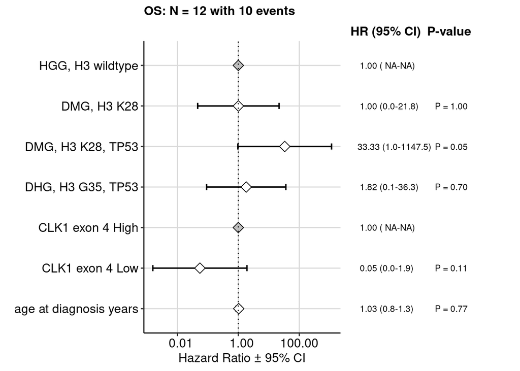

```r
add_os_surv_result <- file.path(results_dir,
                     "cox_HGG_OS_additive_terms_subtype_clk1_status.RDS")

add_model_os <- fit_save_model(survival_df,
                               terms = "mol_sub_group+clk1_status+age_at_diagnosis_years",
                               add_os_surv_result,
                               "multivariate",
                               years_col = "OS_years",
                               status_col = "OS_status"
                              )
add_os_forest_plot <- plotForest(readRDS(add_os_surv_result))
```

```r
ggsave(file.path(plot_dir, "forest_HGG_DMG_OS_add_subtype_clk1_status.pdf"),
       add_os_forest_plot, width = 7.5, height = 3)
```

EFS interaction model:

[figure not shown]

```r
int_efs_surv_result <- file.path(results_dir,
                     "cox_HGG_EFS_interaction_terms_subtype_clk1_status_agedx.RDS")

int_model_efs <- fit_save_model(survival_df,
                               terms = "subgroup_broad*clk1_status*age_at_diagnosis_years",
                               int_efs_surv_result,
                               "multivariate",
                               years_col = "EFS_years",
                               status_col = "EFS_status"
                              )

int_efs_forest_plot <- plotForest(readRDS(int_efs_surv_result),
                                 filter_estimates = FALSE)
```

```r
ggsave(file.path(plot_dir, "forest_HGG_DMG_EFS_int_subtype_clk1_status_agedx.pdf"),
       int_efs_forest_plot, width = 12, height = 5)
```

EFS subgroup additive + clk1 status * age_dx interaction

[figure not shown]

```r
mixed_efs_surv_result <- file.path(results_dir,
                     "cox_HGG_EFS_subtype_interaction_terms_clk1_status_agedx.RDS")

mixed_model_efs <- fit_save_model(survival_df,
                               terms = "mol_sub_group+clk1_status*age_at_diagnosis_years",
                               mixed_efs_surv_result,
                               "multivariate",
                               years_col = "EFS_years",
                               status_col = "EFS_status"
                              )
mixed_efs_forest_plot <- plotForest(readRDS(mixed_efs_surv_result),
                                 filter_estimates = FALSE)
```

```r
ggsave(file.path(plot_dir, "forest_HGG_DMG_EFS_subtype_int_clk1_status_agedx.pdf"),
       mixed_efs_forest_plot, width = 12, height = 4)
```

EFS additive model:

[figure not shown]

```r
add_efs_surv_result <- file.path(results_dir,
                     "cox_HGG_EFS_additive_terms_subtype_clk1_status.RDS")

add_model_efs <- fit_save_model(survival_df,
                               terms = "mol_sub_group+clk1_status+age_at_diagnosis_years",
                               add_efs_surv_result,
                               "multivariate",
                               years_col = "EFS_years",
                               status_col = "EFS_status"
                              )

add_efs_forest_plot <- plotForest(readRDS(add_efs_surv_result))
```

```r
ggsave(file.path(plot_dir, "forest_HGG_DMG_EFS_add_subtype_clk1_status_agedx.pdf"),
       add_efs_forest_plot, width = 7.5, height = 3)
```

There appears to be a subtype x clk1_status interaction effect, such that survival trends may differ in DMG vs. other HGG.

Create models and plots for DMG separately:

```r
kap_os_dmg <- survival_analysis(
  metadata  = survival_df[grepl("DMG", survival_df$mol_sub_group),],
  ind_var = "clk1_status",
  test = "kap.meier",
  metadata_sample_col = "Kids_First_Biospecimen_ID",
  days_col = "OS_days",
  status_col = "OS_status"
)
```

```
Testing model: survival::Surv(OS_days, OS_status) ~ clk1_status with kap.meier
```

```r
readr::write_rds(kap_os_dmg, file.path(results_dir,
                                       "logrank_DMG_OS_CLK1_status.RDS"))

kap_efs_dmg <- survival_analysis(
  metadata  = survival_df[grepl("DMG", survival_df$mol_sub_group),],
  ind_var = "clk1_status",
  test = "kap.meier",
  metadata_sample_col = "Kids_First_Biospecimen_ID",
  days_col = "EFS_days",
  status_col = "EFS_status"
)
```

```
Testing model: survival::Surv(EFS_days, EFS_status) ~ clk1_status with kap.meier
```

```r
readr::write_rds(kap_efs_dmg, file.path(results_dir,
                                        "logrank_DMG_EFS_CLK1_status.RDS"))
```

Plot KM

```r
km_plot <- plotKM(model = list(kap_os_dmg, kap_efs_dmg),
                  variable = "clk1_status",
                  combined = T,
                  title = "")
ggsave(file.path(plot_dir, "km_DMG_OS_EFS_CLK1_status.pdf"), km_plot,
       width = 10, height = 6, units = "in",
       device = "pdf")
```

Generate and plot DMG survival models:

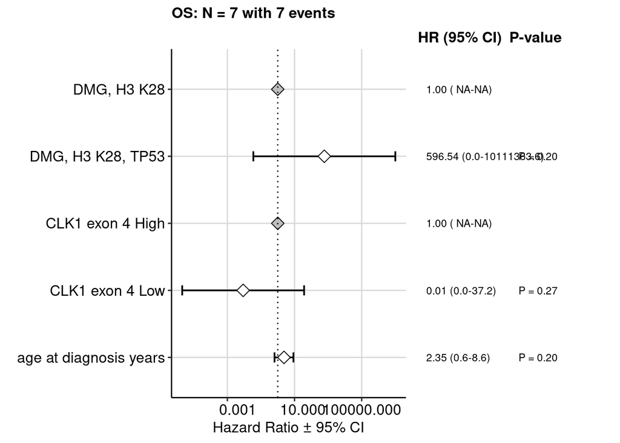

```r
survival_dmg_df <- survival_df %>%
  dplyr::filter(grepl("DMG", mol_sub_group)) %>%
  dplyr::mutate(mol_sub_group = fct_relevel(mol_sub_group,
                                            c("DMG, H3 K28",
                                              "DMG, H3 K28, TP53")))

add_dmg_os_surv_result <- file.path(results_dir,
                     "cox_DMG_OS_additive_terms_subtype_clk1_status.RDS")

add_model_os_dmg <- fit_save_model(survival_dmg_df,
                               terms = "mol_sub_group+clk1_status+age_at_diagnosis_years",
                               add_dmg_os_surv_result,
                               "multivariate",
                               years_col = "OS_years",
                               status_col = "OS_status"
                              )

add_os_dmg_forest_plot <- plotForest(readRDS(add_dmg_os_surv_result))
```

```r
ggsave(file.path(plot_dir, "forest_DMG_OS_add_subtype_clk1_status.pdf"),
       add_os_dmg_forest_plot, width = 7.5, height = 3)
```

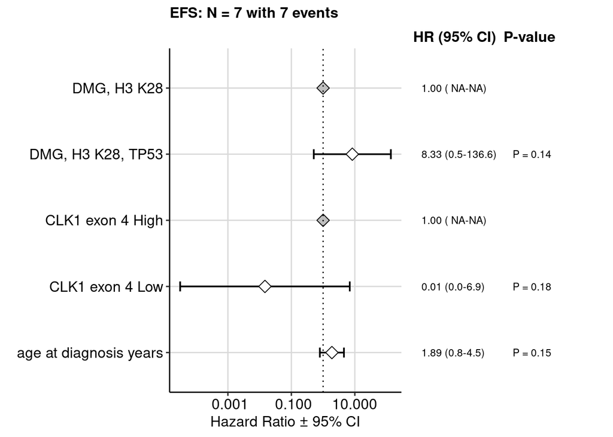

```r
add_dmg_efs_surv_result <- file.path(results_dir,
                     "cox_DMG_EFS_additive_terms_subtype_clk1_status.RDS")

add_model_efs_dmg <- fit_save_model(survival_dmg_df,
                               terms = "mol_sub_group+clk1_status+age_at_diagnosis_years",
                               add_dmg_efs_surv_result,
                               "multivariate",
                               years_col = "EFS_years",
                               status_col = "EFS_status"
                              )

add_efs_dmg_forest_plot <- plotForest(readRDS(add_dmg_efs_surv_result))
```

```r
ggsave(file.path(plot_dir, "forest_DMG_EFS_add_subtype_clk1_status.pdf"),
       add_efs_dmg_forest_plot, width = 7.5, height = 3)
```

Generate and plot models for HGG separately:

```r
kap_os_hgg <- survival_analysis(
  metadata  = survival_df[!grepl("DMG", survival_df$mol_sub_group),],
  ind_var = "clk1_status",
  test = "kap.meier",
  metadata_sample_col = "Kids_First_Biospecimen_ID",
  days_col = "OS_days",
  status_col = "OS_status"
)
```

```
Testing model: survival::Surv(OS_days, OS_status) ~ clk1_status with kap.meier
```

```r
readr::write_rds(kap_os_hgg, file.path(results_dir,
                                       "logrank_HGG_OS_CLK1_status.RDS"))

kap_efs_hgg <- survival_analysis(
  metadata  = survival_df[!grepl("DMG", survival_df$mol_sub_group),],
  ind_var = "clk1_status",
  test = "kap.meier",
  metadata_sample_col = "Kids_First_Biospecimen_ID",
  days_col = "EFS_days",
  status_col = "EFS_status"
)
```

```
Testing model: survival::Surv(EFS_days, EFS_status) ~ clk1_status with kap.meier
```

```r
readr::write_rds(kap_efs_hgg, file.path(results_dir,
                                        "logrank_HGG_EFS_CLK1_status.RDS"))
```

Plot KM

```r
km_plot <- plotKM(model = list(kap_os_hgg, kap_efs_hgg),
                  variable = "clk1_status",
                  combined = T,
                  title = "")
ggsave(file.path(plot_dir, "km_HGG_OS_EFS_CLK1_status.pdf"), km_plot,
       width = 10, height = 6, units = "in",
       device = "pdf")
```

Generate and plot coxph models in HGG:

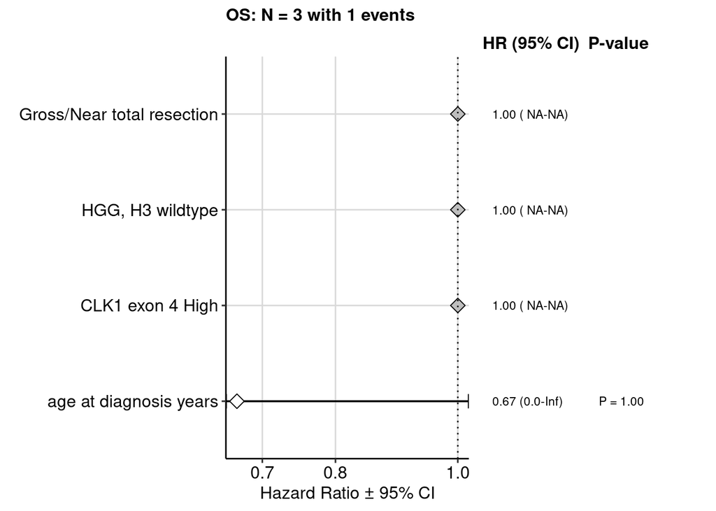

```r
add_hgg_os_surv_result <- file.path(results_dir,
                     "cox_HGG_OS_additive_terms_subtype_clk1_status.RDS")

add_model_os_hgg <- fit_save_model(survival_df[!grepl("DMG", survival_df$mol_sub_group) & !is.na(survival_df$extent_of_tumor_resection) & !survival_df$extent_of_tumor_resection %in% c("Not Reported", "Unavailable"),],
                               terms = "extent_of_tumor_resection+mol_sub_group+clk1_status+age_at_diagnosis_years",
                               add_hgg_os_surv_result,
                               "multivariate",
                               years_col = "OS_years",
                               status_col = "OS_status"
                              )
add_os_hgg_forest_plot <- plotForest(readRDS(add_hgg_os_surv_result))
```

```r
ggsave(file.path(plot_dir, "forest_HGG_OS_add_subtype_clk1_status.pdf"),
       add_os_hgg_forest_plot, width = 7.5, height = 3)
```

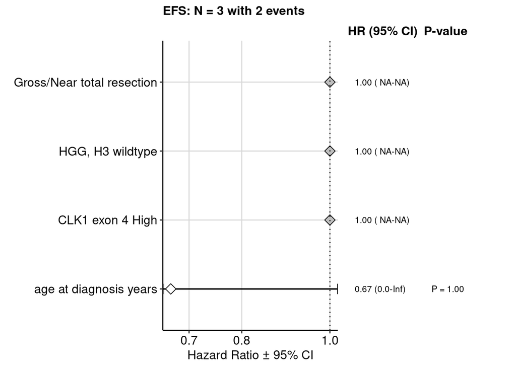

```r
add_hgg_efs_surv_result <- file.path(results_dir,
                     "cox_HGG_EFS_additive_terms_subtype_clk1_status.RDS")

add_model_efs_hgg <- fit_save_model(survival_df[!grepl("DMG", survival_df$mol_sub_group) & !is.na(survival_df$extent_of_tumor_resection) & !survival_df$extent_of_tumor_resection %in% c("Not Reported", "Unavailable"),],
                               terms = "extent_of_tumor_resection+mol_sub_group+clk1_status+age_at_diagnosis_years",
                               add_hgg_efs_surv_result,
                               "multivariate",
                               years_col = "EFS_years",
                               status_col = "EFS_status"
                              )
add_efs_hgg_forest_plot <- plotForest(readRDS(add_hgg_efs_surv_result))
```

```r
ggsave(file.path(plot_dir, "forest_HGG_EFS_add_subtype_clk1_status.pdf"),
       add_efs_hgg_forest_plot, width = 7.5, height = 3)
```